# Bloque 0

Septiembre, 2017

## Temas

- Áreas Marinas Protegidas
- Categorización de AMPs:
  - Según sus objetivos
  - Según sus reglas
  - Ejemplo con Cabo Pulmo

## Áreas Marinas Protegidas (AMP)

- Manejo espacial de actividades humanas (*e.g.* pesca, petróleo, turismo…)
- Evidencia de incrementos en algunos indicadores
  - Biomasa (Aburto-Oropeza et al. 2011; Lester et al. 2009)
  - Densidad (Lester and Halpern 2008)
  - Resiliencia (Micheli et al. 2012)
  - Preservan diversidad genética (Munguía-Vega et al. 2015)
  - ¿Beneficios a pesquerías?

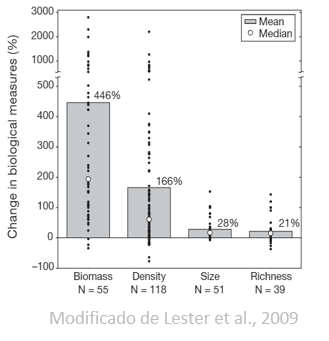

## Gran discusión sobre su (falta de) efectividad pero ¿Por qué no funcionan?

- Respuestas clásicas:
  - Vigilancia
  - Fondos
  - Tamaño
  - Diseño
  - Tiempo
1. Muchos de los casos positivos vienen de Reservas Marinas (zonas de no pesca)
2. Estudios sin control apropiado
3. Tendemos a evaluar objetivos, no intervenciones

## Primer paso: Hablar de lo mismo

## Categorización de AMPs

- Gran diversidad de objetivos = gran diversidad de nombres:
  - Reserva de la Biosfera
  - Zona de Protección de Flora y Fauna
  - Parque Nacional
  - Santuario
  - Y sus sub-zonas…
- Existen dos maneras generales de categorizar una AMP
  - Según sus metas y objetivos (IUCN 2017)
  - Según sus regulaciones (Horta e Costa et al. 2016)

## Categorización de la IUCN

## Características

- Enfocada en objetivos de manejo
- Reconocidas por la ONU y muchos paises
- Incorporadas en legislación
- Describe toda la AMP (no toma en cuenta zonificación)
- [Existen 7 categorías](https://www.iucn.org/es/node/26266)

## Categorias

- Ia Reserva Natural Estricta
- Ib Área de Vida Salvaje
- II Parque Nacional
- III Monumento Natural
- IV Área de Manejo de Hábitat / Especie
- V Paisaje Protegido
- VI Área protegida con uso adecuado de recursos naturales

## Categorias

| Categoría | Descripción |
| --- | --- |
| Ia | Estríctamente para proteger la biodiversidad y geodiversidad. Sirven como puntos de referencia. |
| Ib | Áreas sin (o con poca) modificación, que retienen sus características e influencias naturales sin presencia permanente de humanos. |
| II | Grandes áreas que buscan proteger procesos ecológicos de gran escala así como las especies y ecosistemas en el área y que permite visitantes. |
| III | Protegen montes submarinos, cuevas, monolitos, árboles viejos. |
| IV | Buscan proteger una especie o hábitat en particular, y las acciones de manejo lo reflejan (e.g. repoblamiento / restauración) |
| V | Protegen zonas de interacción, con valor ecológico o cultural, entre humanos y la naturaleza. |
| VI | Protegen ecosistemas, valores culturales y manejo de recursos tradicionales. |

## Desventajas

- Diferencias entre tipos no están muy claras
  - *e.g.* V vs VI
- Enfocadas en objetivos de manejo
  - Comúnmente objetivos de manejo no se alínean con las regulaciones
- Clasifican el AMP entera, ignorando zonificación
- En meta-análisis evaluamos (erróneamente) los objetivos, no intervenciones.

## Categorización de Horta e Costa et al. (2016)

## Categorización de Horta e Costa et al. (2016)

- 8 clases de **zonas** y 5 clases de **AMP**
- Clase de AMP depende de clases de zonas
- Enfoque en regulaciones (usos permitidos)
- Sistema de "árbol de decisiónes"
- Cuantitativo
- Específico a las zonas
- Cálculo del "MPAindex"

## Clases de zona

1. No pesca / No acceso
2. No pesca / Acceso regulado
3. No pesca / Acceso no regulado
4. Extracción altamente regulada
5. Extracción moderadamente regulada
6. Extracción poco regulada
7. Extracción muy poco regulada
8. Extracción no regulada

## Categorización cuantitativa

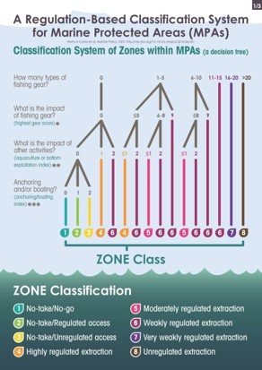

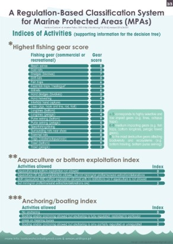

## Clases de AMP

- Se categorizan según el MPAindex como:
  1. Completamente protegida (1-3)
  2. Altamente protegida (3-5)
  3. Moderadamente protegida (5-6)
  4. Poco protegida (6-7)
  5. No protegida (7-8)

## MPAindex

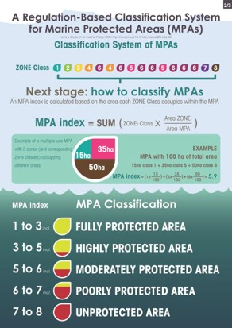

## Ejemplo: Parque Nacional Cabo Pulmo

## Con IUCN

- 7,111 ha totales
- 7,094.8 ha sin SUP (terrestre)
- IUCN:
  - Oficialmente Categoría II (Parque Nacional)
  - Pero sub-zonas tendrían diferentes categorías:
    - actividades de restauración e historia de explotación indicarían IV, V, VI…

## Con MPAindex (Horta e Costa et al. 2016)

\[\sum_{i = 1}^{n}Clase_i\times\frac{Area_i}{AreaAMP}\]

| Zona | Extensión | Artes de pesca | Puntaje más alto AP | Acuacultura y fondo | Embarcaciones | Clase Zona | Clase*(Area/AreaAMP) |
| --- | --- | --- | --- | --- | --- | --- | --- |
| SP1 | 2476.00 | 0 | 0 | 0 | 0 | 1 | 0.35 |
| SP2 | 52.12 | 0 | 0 | 0 | 0 | 1 | 0.01 |
| SASRN1 | 4557.37 | 1 a 5 | 5 | 0 | 2 | 4 | 2.57 |
| SASRN2 | 9.40 | 1 a 5 | 5 | 1 | 3 | 4 | 0.01 |
| Total | 7094.89 |  | NA | NA | NA | NA | 2.93 |

## PNCP es Área completamente protegida

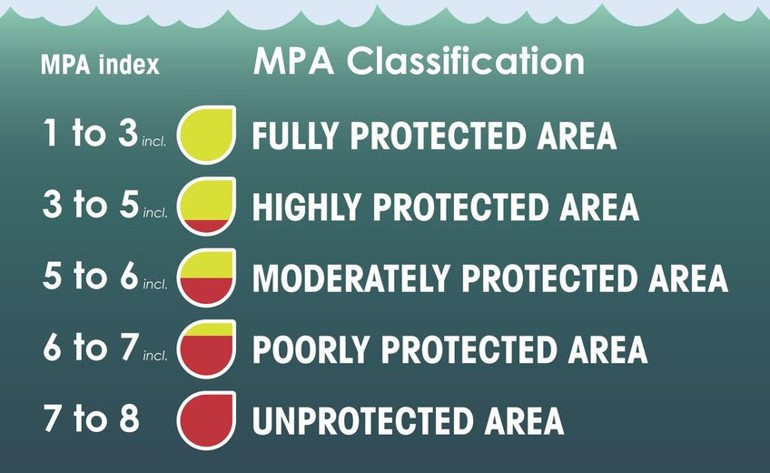

## Utilidad

- Informar manejo:

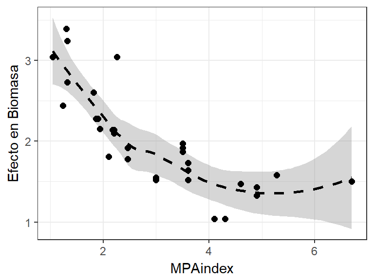

- Forma cuantitativa de clasificar AMPs
- Permite comparar entre AMPs

## Referencias

Aburto-Oropeza, Octavio, Brad Erisman, Grantly R Galland, Ismael Mascareñas-Osorio, Enric Sala, and Exequiel Ezcurra. 2011. “Large Recovery of Fish Biomass in a No-Take Marine Reserve.” *PLoS ONE* 6 (8): e23601. doi:10.1371/journal.pone.0023601.

Horta e Costa, Bárbara, Joachim Claudet, Gustavo Franco, Karim Erzini, Anthony Caro, and Emanuel J. Gonçalves. 2016. “A Regulation-Based Classification System for Marine Protected Areas (Mpas).” *Marine Policy* 72 (October): 192–98. doi:10.1016/j.marpol.2016.06.021.

IUCN. 2017. “Protected Areas Categories.” WEBSITE. *International Union for Conservation of Nature*. https://www.iucn.org/theme/protected-areas/about/protected-areas-categories.

Lester, SE, and BS Halpern. 2008. “Biological Responses in Marine No-Take Reserves Versus Partially Protected Areas.” *Mar. Ecol. Prog. Ser.* 367 (September): 49–56. doi:10.3354/meps07599.

Lester, SE, BS Halpern, K Grorud-Colvert, J Lubchenco, BI Ruttenberg, SD Gaines, S Airamé, and RR Warner. 2009. “Biological Effects Within No-Take Marine Reserves: A Global Synthesis.” *Mar. Ecol. Prog. Ser.* 384 (May): 33–46. doi:10.3354/meps08029.

Micheli, Fiorenza, Andrea Saenz-Arroyo, Ashley Greenley, Leonardo Vazquez, Jose Antonio Espinoza Montes, Marisa Rossetto, and Giulio A De Leo. 2012. “Evidence That Marine Reserves Enhance Resilience to Climatic Impacts.” *PLoS ONE* 7 (7): e40832. doi:10.1371/journal.pone.0040832.

Munguía-Vega, Adrián, Andrea Sáenz-Arroyo, Ashley P. Greenley, Jose Antonio Espinoza-Montes, Stephen R. Palumbi, Marisa Rossetto, and Fiorenza Micheli. 2015. “Marine Reserves Help Preserve Genetic Diversity After Impacts Derived from Climate Variability: Lessons from the Pink Abalone in Baja California.” *Global Ecology and Conservation* 4 (July): 264–76. doi:10.1016/j.gecco.2015.07.005.